# Lab 4: Spatial Predictive Analysis

Analyzing 311 Violations

Author

Huda Abdelnur

Published

April 12, 2026

## Data Loading & Exploration

```r
##Loading in 311 data and Chicago geographic boundaries
chicagoBoundary <-
  st_read("https://raw.githubusercontent.com/urbanSpatial/Public-Policy-Analytics-Landing/master/DATA/Chapter5/chicagoBoundary.geojson") %>%
  st_transform('ESRI:102271')

vacant <- read_csv("C:/Users/hudaa/Documents/CPLN5920/hudabdel-sp-cpln5920/labs/lab_4/data/311_Service_Requests_-_Vacant_and_Abandoned_Buildings_Reported_-_Historical_20260409.csv")

burglaries <- st_read("C:/Users/hudaa/Downloads/burglaries.shp") %>%
  st_transform('ESRI:102271')
```

```r
##clean data to keep cases from 2015 and beyond. Data only has up until 2018
vacant$`DATE SERVICE REQUEST WAS RECEIVED` <- as.Date(vacant$`DATE SERVICE REQUEST WAS RECEIVED`, format = "%m/%d/%Y")
vacant <- vacant[format(vacant$`DATE SERVICE REQUEST WAS RECEIVED`, "%Y") == "2017", ]


##transform vacant csv to spatial dataframe
vacant <- vacant %>%
  drop_na("X COORDINATE", "Y COORDINATE") %>%
  st_as_sf(coords = c("X COORDINATE", "Y COORDINATE"), crs = 3435) %>%  # Illinois State Plane feet
  st_transform(crs = "ESRI:102271")
```

[figure not shown]

```r
##creating a theme to make maps consistent

theme_crime <- function(base_size = 11) {
  theme_minimal(base_size = base_size) +
    theme(
      plot.title = element_text(face = "bold", size = base_size + 1),
      plot.subtitle = element_text(color = "gray30", size = base_size - 1),
      legend.position = "right",
      panel.grid.minor = element_blank(),
      axis.text = element_blank(),
      axis.title = element_blank()
    )
}

# Set as default
theme_set(theme_crime())

##point map of vacant building locations

p1 <- ggplot() +
  geom_sf(data = chicagoBoundary, fill = "gray95", color = "gray60") +
  geom_sf(data = vacant, color = "#d62828", size = 0.1, alpha = 0.4) +
  annotation_north_arrow(
    location = "bl",          # bottom left — or "br", "tl", "tr"
    which_north = "true",
    style = north_arrow_fancy_orienteering(),  # or north_arrow_minimal()
    pad_x = unit(0.2, "in"),
    pad_y = unit(0.2, "in")
  ) +
  labs(
    title = "Vacant Building Locations",
    subtitle = paste0("Chicago 2015-2018, n = ", nrow(vacant))
  ) +
  theme_void() +
  theme(plot.title = element_text(size = 10),
        plot.subtitle = element_text(size = 8))

##density map of vacant buildings
p2 <- ggplot() +
  geom_sf(data = chicagoBoundary, fill = "gray95", color = "gray60") +
  geom_density_2d_filled(
    data = data.frame(st_coordinates(vacant)),
    aes(X, Y),
    alpha = 0.7,
    bins = 8
  ) +
  coord_sf() +  # explicitly force coord_sf to align with chicagoBoundary
  scale_fill_viridis_d(
    option = "plasma",
    direction = -1,
    guide = "none"
  ) +
  labs(
    title = "Density Surface",
    subtitle = "Kernel density estimation"
  ) +
  theme_void() +
  theme(plot.title = element_text(size = 10),
        plot.subtitle = element_text(size = 8))

p1 + p2 +
  plot_annotation(
    title = "Spatial Distribution of Vacant and Abandoned Buildings in Chicago",
    tag_levels = "A",
    theme = theme(plot.title = element_text(size = 12, hjust = 0.5))
  )
```

## Fishnet Grid Creation

```r
##create a 500M X 500M fishnet
fishnet <- st_make_grid(
  chicagoBoundary,
  cellsize = 500,  # 500 meters per cell
  square = TRUE
) %>%
  st_sf() %>%
  mutate(uniqueID = row_number()) %>%
  st_transform('ESRI:102271')

# Keep only cells that intersect Chicago
fishnet <- fishnet[chicagoBoundary, ]

# Spatial join: which cell contains each burglary?
burglaries_fishnet <- st_join(burglaries, fishnet, join = st_within) %>%
  st_drop_geometry() %>%
  group_by(uniqueID) %>%
  summarize(countBurglaries = n(), .groups = "drop")


# Join back to fishnet (cells with 0 burglaries will be NA)
fishnet <- fishnet %>%
  left_join(burglaries_fishnet, by = "uniqueID") %>%
  mutate(countBurglaries = replace_na(countBurglaries, 0))


# Spatial join: which cells have vacant properties?
vacant_fishnet <- st_join(vacant, fishnet, join = st_within) %>%
  st_drop_geometry() %>%
  group_by(uniqueID) %>%
  summarize(countvacant = n())

# Join back to fishnet (cells with 0 vacant buildings will be NA)
fishnet <- fishnet %>%
  left_join(vacant_fishnet, by = "uniqueID") %>%
  mutate(countvacant = replace_na(countvacant, 0))

# Summary statistics

cat("\nCells with zero vacant buildings:",
    sum(fishnet$countvacant == 0),
    "/", nrow(fishnet),
    "(", round(100 * sum(fishnet$countvacant == 0) / nrow(fishnet), 1), "%)\n")
```

```
Cells with zero vacant buildings: 1583 / 2458 ( 64.4 %)
```

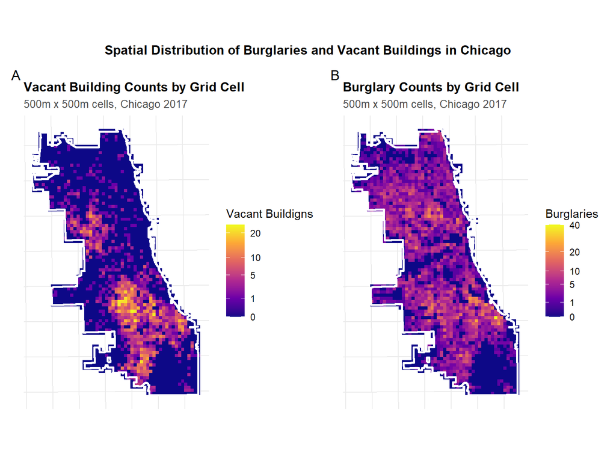

```r
# Visualize aggregated counts
p3 <- ggplot() +
  geom_sf(data = fishnet, aes(fill = countvacant), color = NA) +
  geom_sf(data = chicagoBoundary, fill = NA, color = "white", linewidth = 1) +
  scale_fill_viridis_c(
    name = "Vacant Buildigns",
    option = "plasma",
    trans = "sqrt",  # Square root for better visualization of skewed data
    breaks = c(0, 1, 5, 10, 20, 40)
  ) +
  labs(
    title = "Vacant Building Counts by Grid Cell",
    subtitle = "500m x 500m cells, Chicago 2017"
  ) +
  theme_crime()

p4 <- ggplot() +
  geom_sf(data = fishnet, aes(fill = countBurglaries), color = NA) +
  geom_sf(data = chicagoBoundary, fill = NA, color = "white", linewidth = 1) +
  scale_fill_viridis_c(
    name = "Burglaries",
    option = "plasma",
    trans = "sqrt",  # Square root for better visualization of skewed data
    breaks = c(0, 1, 5, 10, 20, 40)
  ) +
  labs(
    title = "Burglary Counts by Grid Cell",
    subtitle = "500m x 500m cells, Chicago 2017"
  ) +
  theme_crime()

p3 + p4 + plot_annotation(
    title = "Spatial Distribution of Burglaries and Vacant Buildings in Chicago",
    tag_levels = "A",
    theme = theme(plot.title = element_text(size = 12, hjust = 0.5))
  )
```

```r
# Convert vacant to point pattern analysis.
vacant_ppp <- as.ppp(
  st_coordinates(vacant),
  W = as.owin(st_bbox(chicagoBoundary))
)

# Calculate KDE with 1km bandwidth
kde_vacant <- density.ppp(
  vacant_ppp,
  sigma = 1000,  # 1km bandwidth
  edge = TRUE    # Edge correction
)

# Convert to terra raster (modern approach, not raster::raster)
kde_raster <- rast(kde_vacant)

# Extract KDE values to fishnet cells
fishnet <- fishnet %>%
  mutate(
    kde_value = terra::extract(
      kde_raster,
      vect(fishnet),
      fun = mean,
      na.rm = TRUE
    )[, 2]  # Extract just the values column
  )


# Convert vacant to point pattern analysis.
b_ppp <- as.ppp(
  st_coordinates(burglaries),
  W = as.owin(st_bbox(chicagoBoundary))
)

# Calculate KDE with 1km bandwidth
kde_b <- density.ppp(
  b_ppp,
  sigma = 1000,  # 1km bandwidth
  edge = TRUE    # Edge correction
)

# Convert to terra raster (modern approach, not raster::raster)
kde_raster_b <- rast(kde_b)

# Extract KDE values to fishnet cells
fishnet <- fishnet %>%
  mutate(
    kde_b = terra::extract(
      kde_raster_b,
      vect(fishnet),
      fun = mean,
      na.rm = TRUE
    )[, 2]  # Extract just the values column
  )
```

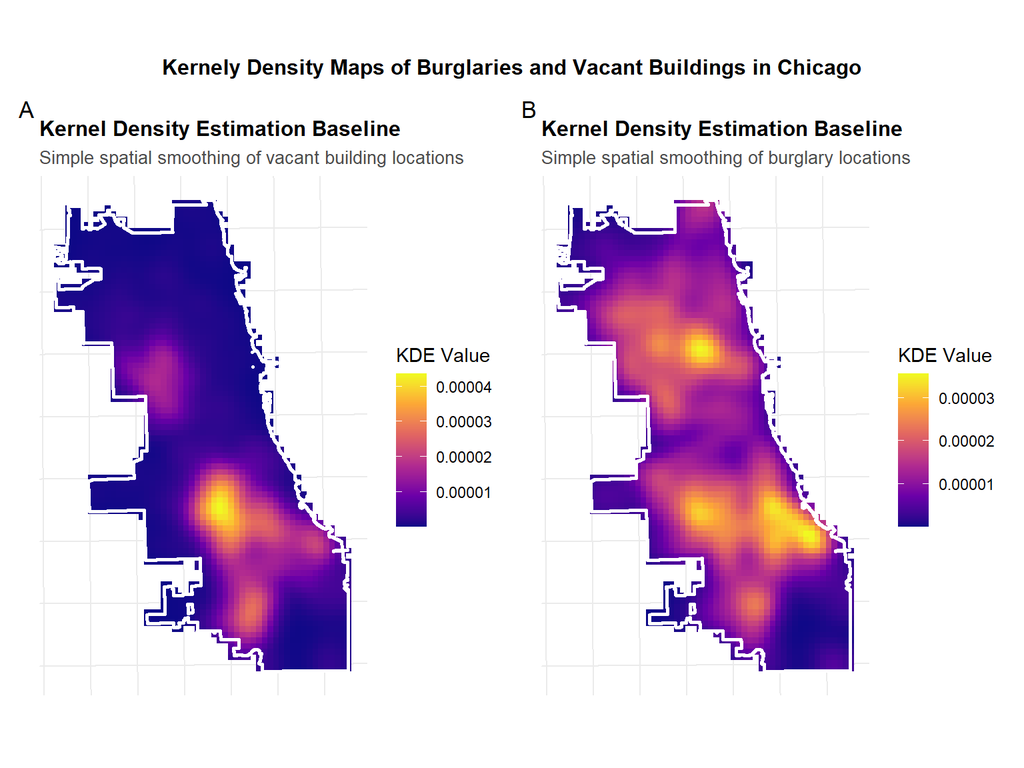

```r
p5 <- ggplot() +
  geom_sf(data = fishnet, aes(fill = kde_value), color = NA) +
  geom_sf(data = chicagoBoundary, fill = NA, color = "white", linewidth = 1) +
  scale_fill_viridis_c(
    name = "KDE Value",
    option = "plasma"
  ) +
  labs(
    title = "Kernel Density Estimation Baseline",
    subtitle = "Simple spatial smoothing of vacant building locations"
  ) +
  theme_crime()


p6 <- ggplot() +
  geom_sf(data = fishnet, aes(fill = kde_b), color = NA) +
  geom_sf(data = chicagoBoundary, fill = NA, color = "white", linewidth = 1) +
  scale_fill_viridis_c(
    name = "KDE Value",
    option = "plasma"
  ) +
  labs(
    title = "Kernel Density Estimation Baseline",
    subtitle = "Simple spatial smoothing of burglary locations"
  ) +
  theme_crime()

p5 + p6 + plot_annotation(
    title = "Kernely Density Maps of Burglaries and Vacant Buildings in Chicago",
    tag_levels = "A",
    theme = theme(plot.title = element_text(size = 12, hjust = 0.5))
  )
```

## Spatial Features

```r
# Calculate mean distance to 3 nearest vacant buildings
# (Do this OUTSIDE of mutate to avoid sf conflicts)

# Get coordinates
fishnet_coords <- st_coordinates(st_centroid(fishnet))
vacant_coords <- st_coordinates(vacant)

# Calculate k nearest neighbors and distances.
nn_result <- get.knnx(vacant_coords, fishnet_coords, k = 3)

# Add to fishnet
fishnet <- fishnet %>%
  mutate(
    vacant.nn = rowMeans(nn_result$nn.dist)
  )

summary(fishnet$vacant.nn)
```

```
    Min.  1st Qu.   Median     Mean  3rd Qu.     Max.
   3.622  290.576  613.232  785.608 1068.276 4773.328
```

```r
# Function to calculate Local Moran's I, essentially this function will be applied to the vacant dataset
calculate_local_morans <- function(data, variable, k = 5) {

  # Create spatial weights
  coords <- st_coordinates(st_centroid(data))
  neighbors <- knn2nb(knearneigh(coords, k = k))
  weights <- nb2listw(neighbors, style = "W", zero.policy = TRUE)

  # Calculate Local Moran's I
  local_moran <- localmoran(data[[variable]], weights)

  # Classify clusters
  mean_val <- mean(data[[variable]], na.rm = TRUE)

  data %>%
    mutate(
      local_i = local_moran[, 1],
      p_value = local_moran[, 5],
      is_significant = p_value < 0.05,

      moran_class = case_when(
        !is_significant ~ "Not Significant",
        local_i > 0 & .data[[variable]] > mean_val ~ "High-High",
        local_i > 0 & .data[[variable]] <= mean_val ~ "Low-Low",
        local_i < 0 & .data[[variable]] > mean_val ~ "High-Low",
        local_i < 0 & .data[[variable]] <= mean_val ~ "Low-High",
        TRUE ~ "Not Significant"
      )
    )
}

# Apply to vacant building dataset
fishnet <- calculate_local_morans(fishnet, "countvacant", k = 5)
```

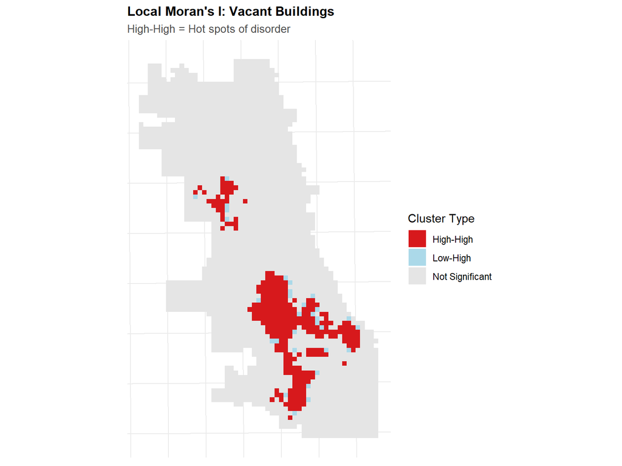

```r
# Visualize hot spots
ggplot() +
  geom_sf(
    data = fishnet,
    aes(fill = moran_class),
    color = NA
  ) +
  scale_fill_manual(
    values = c(
      "High-High" = "#d7191c",
      "High-Low" = "#fdae61",
      "Low-High" = "#abd9e9",
      "Low-Low" = "#2c7bb6",
      "Not Significant" = "gray90"
    ),
    name = "Cluster Type"
  ) +
  labs(
    title = "Local Moran's I: Vacant Buildings",
    subtitle = "High-High = Hot spots of disorder"
  ) +
  theme_crime()
```

```r
# Get centroids of "High-High" cells (hot spots)
hotspots <- fishnet %>%
  filter(moran_class == "High-High") %>%
  st_centroid()

# Calculate distance from each cell to nearest hot spot
if (nrow(hotspots) > 0) {
  fishnet <- fishnet %>%
    mutate(
      dist_to_hotspot = as.numeric(
        st_distance(st_centroid(fishnet), hotspots %>% st_union())
      )
    )


  cat("  - Number of hot spot cells:", nrow(hotspots), "\n")
} else {
  fishnet <- fishnet %>%
    mutate(dist_to_hotspot = 0)
  cat("⚠ No significant hot spots found\n")
}
```

```
  - Number of hot spot cells: 278
```

## Count Regression Models

```r
# Create clean modeling dataset

# load police districts and join them to fishnet
policeDistricts <-
  st_read("https://data.cityofchicago.org/api/geospatial/24zt-jpfn?method=export&format=GeoJSON") %>%
  st_transform('ESRI:102271') %>%
  dplyr::select(District = dist_num)

# Join district information to fishnet
fishnet <- st_join(
  fishnet,
  policeDistricts,
  join = st_within,
  left = TRUE
) %>%
  filter(!is.na(District))  # Remove cells outside districts


cat("  - Districts:", length(unique(fishnet$District)), "\n")
cat("  - Cells:", nrow(fishnet), "\n")

fishnet_model <- fishnet %>%
  st_drop_geometry() %>%
  dplyr::select(
    uniqueID,
    kde_value,
    kde_b,
    local_i,
    countvacant,
    vacant.nn,
    dist_to_hotspot,
    countBurglaries,
    District
  ) %>%
  na.omit()  # Remove any remaining NAs


districts <- unique(fishnet_model$District)
cv_results <- tibble()
```

```r
# Fit Poisson regression
model_poisson <- glm(
  countBurglaries ~  countvacant + vacant.nn +
    dist_to_hotspot,
  data = fishnet_model,
  family = "poisson"
)

# Summary
summary(model_poisson)
```

```
Call:
glm(formula = countBurglaries ~ countvacant + vacant.nn + dist_to_hotspot,
    family = "poisson", data = fishnet_model)

Coefficients:
                    Estimate   Std. Error z value            Pr(>|z|)
(Intercept)      1.677350078  0.029710962  56.456 <0.0000000000000002 ***
countvacant      0.038182758  0.003498061  10.915 <0.0000000000000002 ***
vacant.nn       -0.000974593  0.000049761 -19.585 <0.0000000000000002 ***
dist_to_hotspot  0.000006865  0.000006048   1.135               0.256
---
Signif. codes:  0 '***' 0.001 '**' 0.01 '*' 0.05 '.' 0.1 ' ' 1

(Dispersion parameter for poisson family taken to be 1)

    Null deviance: 6710.3  on 1707  degrees of freedom
Residual deviance: 5236.6  on 1704  degrees of freedom
AIC: 9304.9

Number of Fisher Scoring iterations: 6
```

```r
# Calculate dispersion parameter
dispersion <- sum(residuals(model_poisson, type = "pearson")^2) /
              model_poisson$df.residual

cat("Dispersion parameter:", round(dispersion, 2), "\n")
```

```
Dispersion parameter: 3.34
```

```r
cat("Rule of thumb: >1.5 suggests overdispersion\n")
```

```
Rule of thumb: >1.5 suggests overdispersion
```

```r
if (dispersion > 1.5) {
  cat("⚠ Overdispersion detected! Consider Negative Binomial model.\n")
} else {
  cat("✓ Dispersion looks okay for Poisson model.\n")
}
```

```
⚠ Overdispersion detected! Consider Negative Binomial model.
```

Negative Binomial

```r
# Fit Negative Binomial model
model_nb <- glm.nb(
  countBurglaries ~ countvacant + vacant.nn +
    dist_to_hotspot,
  data = fishnet_model
)

# Summary
summary(model_nb)
```

```
Call:
glm.nb(formula = countBurglaries ~ countvacant + vacant.nn +
    dist_to_hotspot, data = fishnet_model, init.theta = 1.467026578,
    link = log)

Coefficients:
                   Estimate  Std. Error z value             Pr(>|z|)
(Intercept)      1.62506475  0.05543976  29.312 < 0.0000000000000002 ***
countvacant      0.04545058  0.00812008   5.597         0.0000000218 ***
vacant.nn       -0.00098330  0.00007590 -12.954 < 0.0000000000000002 ***
dist_to_hotspot  0.00002022  0.00001030   1.963               0.0497 *
---
Signif. codes:  0 '***' 0.001 '**' 0.01 '*' 0.05 '.' 0.1 ' ' 1

(Dispersion parameter for Negative Binomial(1.467) family taken to be 1)

    Null deviance: 2416.9  on 1707  degrees of freedom
Residual deviance: 1962.9  on 1704  degrees of freedom
AIC: 7776.1

Number of Fisher Scoring iterations: 1

              Theta:  1.4670
          Std. Err.:  0.0837

 2 x log-likelihood:  -7766.1240
```

```r
# Compare AIC (lower is better)
cat("\nModel Comparison:\n")
```

```
Model Comparison:
```

```r
cat("Poisson AIC:", round(AIC(model_poisson), 1), "\n")
```

```
Poisson AIC: 9304.9
```

```r
cat("Negative Binomial AIC:", round(AIC(model_nb), 1), "\n")
```

```
Negative Binomial AIC: 7776.1
```

## Spatial Cross-Validation (2017)

```r
cat("Running LOGO Cross-Validation...\n")
```

```
Running LOGO Cross-Validation...
```

```r
for (i in seq_along(districts)) {

  test_district <- districts[i]

  # Split data
  train_data <- fishnet_model %>% filter(District != test_district)
  test_data <- fishnet_model %>% filter(District == test_district)

  # Fit model on training data
  model_cv <- glm.nb(
    countBurglaries ~ countvacant + vacant.nn +
      dist_to_hotspot,
    data = train_data
  )

  # Predict on test data
  test_data <- test_data %>%
    mutate(
      prediction = predict(model_cv, test_data, type = "response")
    )

  # Calculate metrics
  mae <- mean(abs(test_data$countBurglaries - test_data$prediction))
  rmse <- sqrt(mean((test_data$countBurglaries - test_data$prediction)^2))

  # Store results
  cv_results <- bind_rows(
    cv_results,
    tibble(
      fold = i,
      test_district = test_district,
      n_test = nrow(test_data),
      mae = mae,
      rmse = rmse
    )
  )

  cat("  Fold", i, "/", length(districts), "- District", test_district,
      "- MAE:", round(mae, 2), "\n")
}
```

```
  Fold 1 / 22 - District 5 - MAE: 2.53
  Fold 2 / 22 - District 4 - MAE: 2.79
  Fold 3 / 22 - District 22 - MAE: 2.11
  Fold 4 / 22 - District 6 - MAE: 3.02
  Fold 5 / 22 - District 8 - MAE: 2.47
  Fold 6 / 22 - District 7 - MAE: 3.68
  Fold 7 / 22 - District 3 - MAE: 5.54
  Fold 8 / 22 - District 2 - MAE: 2.72
  Fold 9 / 22 - District 9 - MAE: 2.48
  Fold 10 / 22 - District 10 - MAE: 2.13
  Fold 11 / 22 - District 1 - MAE: 2.38
  Fold 12 / 22 - District 12 - MAE: 3.59
  Fold 13 / 22 - District 15 - MAE: 2.25
  Fold 14 / 22 - District 11 - MAE: 3.01
  Fold 15 / 22 - District 18 - MAE: 2.42
  Fold 16 / 22 - District 25 - MAE: 2.7
  Fold 17 / 22 - District 14 - MAE: 3.18
  Fold 18 / 22 - District 19 - MAE: 2.46
  Fold 19 / 22 - District 16 - MAE: 1.96
  Fold 20 / 22 - District 17 - MAE: 1.69
  Fold 21 / 22 - District 20 - MAE: 1.76
  Fold 22 / 22 - District 24 - MAE: 2
```

```r
# Overall results
cat("Mean MAE:", round(mean(cv_results$mae), 2), "\n")
```

```
Mean MAE: 2.68
```

```r
cat("Mean RMSE:", round(mean(cv_results$rmse), 2), "\n")
```

```
Mean RMSE: 3.52
```

```r
# Show results
cv_results %>%
  arrange(desc(mae)) %>%
  kable(
    digits = 2,
    caption = "LOGO CV Results by District"
  ) %>%
  kable_styling(bootstrap_options = c("striped", "hover"))
```

LOGO CV Results by District

| fold | test_district | n_test | mae | rmse |
| --- | --- | --- | --- | --- |
| 7 | 3 | 43 | 5.54 | 7.26 |
| 6 | 7 | 52 | 3.68 | 4.67 |
| 12 | 12 | 73 | 3.59 | 5.04 |
| 17 | 14 | 46 | 3.18 | 4.64 |
| 4 | 6 | 63 | 3.02 | 4.21 |
| 14 | 11 | 43 | 3.01 | 3.43 |
| 2 | 4 | 235 | 2.79 | 3.83 |
| 8 | 2 | 56 | 2.72 | 3.39 |
| 16 | 25 | 85 | 2.70 | 3.77 |
| 1 | 5 | 98 | 2.53 | 2.92 |
| 9 | 9 | 107 | 2.48 | 2.91 |
| 5 | 8 | 197 | 2.47 | 3.45 |
| 18 | 19 | 63 | 2.46 | 3.20 |
| 15 | 18 | 30 | 2.42 | 4.09 |
| 11 | 1 | 28 | 2.38 | 3.05 |
| 13 | 15 | 32 | 2.25 | 2.82 |
| 10 | 10 | 63 | 2.13 | 2.78 |
| 3 | 22 | 112 | 2.11 | 2.62 |
| 22 | 24 | 41 | 2.00 | 2.91 |
| 19 | 16 | 129 | 1.96 | 2.30 |
| 21 | 20 | 30 | 1.76 | 2.14 |
| 20 | 17 | 82 | 1.69 | 2.11 |

## Model Evaluation

```r
# Fit final model on all data
final_model <- glm.nb(
  countBurglaries ~ countvacant + vacant.nn +
    dist_to_hotspot,
  data = fishnet_model
)

# Add predictions back to fishnet
fishnet <- fishnet %>%
  mutate(
    prediction_nb = predict(final_model, fishnet_model, type = "response")[match(uniqueID, fishnet_model$uniqueID)]
  )

# Also add KDE predictions (normalize to same scale as counts)
kde_sum <- sum(fishnet$kde_b, na.rm = TRUE)
count_sum <- sum(fishnet$countBurglaries, na.rm = TRUE)
fishnet <- fishnet %>%
  mutate(
    prediction_kde = (kde_b / kde_sum) * count_sum
  )
```

## Compare Model vs. KDE Baseline

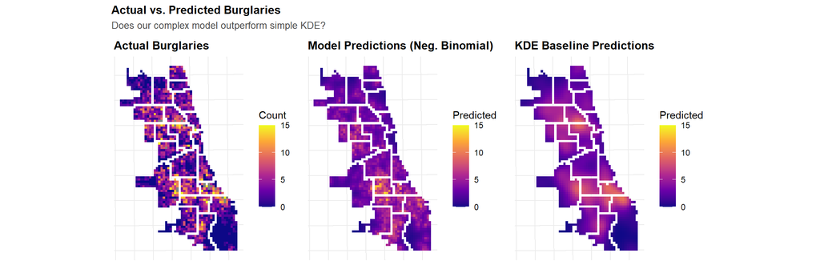

```r
# Create three maps
p7 <- ggplot() +
  geom_sf(data = fishnet, aes(fill = countBurglaries), color = NA) +
  scale_fill_viridis_c(name = "Count", option = "plasma", limits = c(0, 15)) +
  labs(title = "Actual Burglaries") +
  theme_crime()

p8 <- ggplot() +
  geom_sf(data = fishnet, aes(fill = prediction_nb), color = NA) +
  scale_fill_viridis_c(name = "Predicted", option = "plasma", limits = c(0, 15)) +
  labs(title = "Model Predictions (Neg. Binomial)") +
  theme_crime()

p9 <- ggplot() +
  geom_sf(data = fishnet, aes(fill = prediction_kde), color = NA) +
  scale_fill_viridis_c(name = "Predicted", option = "plasma", limits = c(0, 15)) +
  labs(title = "KDE Baseline Predictions") +
  theme_crime()

p7 + p8 + p9 +
  plot_annotation(
    title = "Actual vs. Predicted Burglaries",
    subtitle = "Does our complex model outperform simple KDE?"
  )
```

```r
# Calculate performance metrics
comparison <- fishnet %>%
  st_drop_geometry() %>%
  filter(!is.na(prediction_nb), !is.na(prediction_kde)) %>%
  summarize(
    model_mae = mean(abs(countBurglaries - prediction_nb)),
    model_rmse = sqrt(mean((countBurglaries - prediction_nb)^2)),
    kde_mae = mean(abs(countBurglaries - prediction_kde)),
    kde_rmse = sqrt(mean((countBurglaries - prediction_kde)^2))
  )

comparison %>%
  pivot_longer(everything(), names_to = "metric", values_to = "value") %>%
  separate(metric, into = c("approach", "metric"), sep = "_") %>%
  pivot_wider(names_from = metric, values_from = value) %>%
  kable(
    digits = 2,
    caption = "Model Performance Comparison"
  ) %>%
  kable_styling(bootstrap_options = c("striped", "hover"))
```

Model Performance Comparison

| approach | mae | rmse |
| --- | --- | --- |
| model | 2.51 | 3.46 |
| kde | 2.06 | 2.95 |

## Negative Binomial Model Table

```r
# Create nice summary table
model_summary <- broom::tidy(final_model, exponentiate = TRUE) %>%
  mutate(
    across(where(is.numeric), ~round(., 3))
  )

model_summary %>%
  kable(
    caption = "Final Negative Binomial Model Coefficients (Exponentiated)",
    col.names = c("Variable", "Rate Ratio", "Std. Error", "Z", "P-Value")
  ) %>%
  kable_styling(bootstrap_options = c("striped", "hover")) %>%
  footnote(
    general = "Rate ratios > 1 indicate positive association with burglary counts."
  )
```

Final Negative Binomial Model Coefficients (Exponentiated)

| Variable | Rate Ratio | Std. Error | Z | P-Value |
| --- | --- | --- | --- | --- |
| (Intercept) | 5.079 | 0.055 | 29.312 | 0.00 |
| countvacant | 1.046 | 0.008 | 5.597 | 0.00 |
| vacant.nn | 0.999 | 0.000 | -12.954 | 0.00 |
| dist_to_hotspot | 1.000 | 0.000 | 1.963 | 0.05 |

Note:  
Rate ratios > 1 indicate positive association with burglary counts.

**Intro** The following passage will go through each major step to conduct this analysis in predicting burglaries in Chicago in 2017.

This analysis integrated four types of datasets to perform its analysis: chicago boundaries, burglaries in 2017, 311 vacant building calls from 2017, and police districts. Vacant building calls were filtered to 2017 to align with the timeframe from the burglary dataset to avoid bias or enhance accuracy. Literature highlights that the presence of crime is associated with disorder in the built environment also known as “broken window theory”, therefore 311 calls on vacant and abandoned buildings was utilized to understand if it can predict burglaries.

**Data Exploration**

Two maps are created to visualize the spatial distribution of vacant and abandoned buildings in Chicago. The point map displays the exact locations of reported buildings, while the density map (kernel density estimation) highlights areas of higher concentration.

Together, these visualizations provide an initial understanding of spatial patterns, revealing clusters and potential hotspots of vacancy across the city. This step is essential in exploratory data analysis, as it helps identify underlying spatial structure and informs subsequent modeling decisions, including the selection of relevant spatial features and predictors.

**Fishnet Grid**

In the next step, a fishnet grid of 500 by 500 meters is created to standardize the spatial unit of analysis. This grid allows for the aggregation of vacant building reports and burglary incidents within uniformly sized cells, making it possible to compare counts across space in a consistent way.

Aggregating the data to this grid helps reveal where both phenomena are concentrated and how frequently they occur within each area. However, this process comes with a tradeoff: while it improves comparability and enables spatial modeling, it does not preserve the exact point locations of individual events.

Additionally, the choice of grid size is methodologically important. Different grid resolutions can produce different spatial patterns, as larger cells may smooth variation while smaller cells may highlight more localized clustering. This reflects the Modifiable Areal Unit Problem (MAUP), where analytical results are sensitive to the scale and zoning of spatial units.

**Spatial Features**

A kernel density estimation (KDE) is developed in the next step to serve as a baseline non-parametric approach. This is implemented through point pattern analysis, where the spatial distribution of events is used to estimate a continuous surface of intensity. A bandwidth of 1000 meters is applied, allowing the model to capture the concentration of events within a defined spatial radius. The resulting KDE values are then extracted and assigned to the fishnet cells, enabling visualization of hotspots for both burglaries and vacant buildings.

Building on this, additional spatial features are constructed to incorporate spatial context into the regression model and assess whether patterns in vacant building reports can help predict burglary occurrences. The first feature is a k-nearest neighbor measure, calculated as the mean distance to the three nearest vacant buildings, which captures the degree of local clustering.

A distance-to-hotspot measure is created by identifying high-high clusters of vacant buildings and calculating the distance from each fishnet cell centroid to the nearest hotspot. This captures proximity to areas of concentrated vacancy, providing an additional spatial predictor for the model.

**Local Moran**

Next, a Local Moran’s I statistic is computed. Unlike Global Moran’s I, which summarizes overall spatial autocorrelation, Local Moran’s I identifies clustering at a more granular level, distinguishing between high-high clusters, low-low clusters, and spatial outliers. This function is applied to the fishnet using the count of vacant buildings, with k = 5 defining the number of nearest neighbors used to construct spatial weights.

**Count Regression**

Now that spatial features have been created, they can be integrated into regression models to help understand if 311 vacant building calls can predict burglaries. Considering this is count data, a poisson model is utilized. The model utilizes count of vacant calls within each fishnet cell, the nearest neighbor spatial feature, and distance to hot spots to predict burglaries. The Poisson regression results indicate that vacant building reports are positively associated with burglary counts. Specifically, a one-unit increase in vacant building reports is associated with approximately a 3.9% increase in expected burglaries, holding other factors constant. Additionally, the mean distance to the three nearest vacant buildings has a small but statistically significant negative association, suggesting that burglaries are more likely to occur in areas where vacant buildings are more spatially clustered. In contrast, distance to vacant building hotspots is not statistically significant, indicating it does not meaningfully contribute to predicting burglary counts in this model. However, overdispersion was detected, with the model having a dispersion of 3.4 which is higher than the threshold of 1.5. This indicates that a negative binomial model is more suitable for this dataset. In the negative binomial model all three variables in the model were statistically significant and the mean distance to the three nearest vacant buildings still had a negative association with burglaries, while the remaining variables had positive associations.

The AIC is utilized to compare models to understand model performance. The negative binomial model performed better with an AIC of 7776.1 and the poisson model reporting an AIC of 9304.9.

**Validation**

**Model Comparison**

However, while KDE provides stronger predictive accuracy, it does not offer insight into the relationship between vacant buildings and burglary. In contrast, the negative binomial model allows for interpretation of how vacant building prevalence and spatial features are associated with burglary counts.

This highlights an important tradeoff between predictive performance and interpretability: simpler spatial models may outperform in prediction, but the negative binomial provides coefficients for each variable allowing us to understand the magnitude of each variable’s ability to predict the outcome, illustrating a more comprehensive picture of the variance within the dataset.

According to the maps, the negative binomial model performs poorly for areas along the perimeter of Chicago, more specifically the Southern edge. It performs well in the central areas of Chicago. The KDE map generally overall performs well throughout the city.